# Risk Factor Analysis

## Outcome Variable

**Outcome Variable:** whz

## Predictor Variables

**Intervention Variable:** impsan

**Adjustment Set:**

- arm
- sex
- W_mage
- meducyrs
- feducyrs
- hhwealth_quart
- hfoodsec
- W_mhtcm
- W_nrooms
- W_nchldlt5
- W_parity
- impfloor
- safeh20
- delta_W_mage
- delta_meducyrs
- delta_feducyrs
- delta_hhwealth_quart
- delta_hfoodsec
- delta_W_mhtcm
- delta_W_nrooms
- delta_W_nchldlt5
- delta_W_parity
- delta_impfloor
- delta_safeh20

## Stratifying Variables

The analysis was stratified on these variable(s):

- agecat
- studyid
- country

## Data Summary

| agecat | studyid | country | impsan | n_cell | n |
| --- | --- | --- | --- | --- | --- |
| Birth | ki0047075b-MAL-ED | BANGLADESH | 1 | 186 | 222 |
| Birth | ki0047075b-MAL-ED | BANGLADESH | 0 | 36 | 222 |
| Birth | ki0047075b-MAL-ED | BRAZIL | 1 | 163 | 167 |
| Birth | ki0047075b-MAL-ED | BRAZIL | 0 | 4 | 167 |
| Birth | ki0047075b-MAL-ED | INDIA | 1 | 90 | 188 |
| Birth | ki0047075b-MAL-ED | INDIA | 0 | 98 | 188 |
| Birth | ki0047075b-MAL-ED | NEPAL | 1 | 165 | 166 |
| Birth | ki0047075b-MAL-ED | NEPAL | 0 | 1 | 166 |
| Birth | ki0047075b-MAL-ED | PERU | 1 | 60 | 243 |
| Birth | ki0047075b-MAL-ED | PERU | 0 | 183 | 243 |
| Birth | ki0047075b-MAL-ED | SOUTH AFRICA | 1 | 2 | 211 |
| Birth | ki0047075b-MAL-ED | SOUTH AFRICA | 0 | 209 | 211 |
| Birth | ki0047075b-MAL-ED | TANZANIA, UNITED REPUBLIC OF | 1 | 0 | 109 |
| Birth | ki0047075b-MAL-ED | TANZANIA, UNITED REPUBLIC OF | 0 | 109 | 109 |
| Birth | ki1017093-NIH-Birth | BANGLADESH | 1 | 9 | 28 |
| Birth | ki1017093-NIH-Birth | BANGLADESH | 0 | 19 | 28 |
| Birth | ki1017093c-NIH-Crypto | BANGLADESH | 1 | 21 | 23 |
| Birth | ki1017093c-NIH-Crypto | BANGLADESH | 0 | 2 | 23 |
| Birth | ki1114097-CONTENT | PERU | 1 | 1 | 2 |
| Birth | ki1114097-CONTENT | PERU | 0 | 1 | 2 |
| Birth | ki1135781-COHORTS | GUATEMALA | 1 | 43 | 449 |
| Birth | ki1135781-COHORTS | GUATEMALA | 0 | 406 | 449 |
| Birth | ki1135781-COHORTS | INDIA | 1 | 1685 | 4461 |
| Birth | ki1135781-COHORTS | INDIA | 0 | 2776 | 4461 |
| Birth | ki1135781-COHORTS | PHILIPPINES | 1 | 177 | 1126 |
| Birth | ki1135781-COHORTS | PHILIPPINES | 0 | 949 | 1126 |
| Birth | kiGH5241-JiVitA-3 | BANGLADESH | 1 | 10724 | 15689 |
| Birth | kiGH5241-JiVitA-3 | BANGLADESH | 0 | 4965 | 15689 |
| Birth | kiGH5241-JiVitA-4 | BANGLADESH | 1 | 503 | 683 |
| Birth | kiGH5241-JiVitA-4 | BANGLADESH | 0 | 180 | 683 |

[output cut: 68 more lines]

The following strata were considered:

- agecat: 24 months, studyid: ki0047075b-MAL-ED, country: BANGLADESH
- agecat: 24 months, studyid: ki0047075b-MAL-ED, country: BRAZIL
- agecat: 24 months, studyid: ki0047075b-MAL-ED, country: INDIA
- agecat: 24 months, studyid: ki0047075b-MAL-ED, country: NEPAL
- agecat: 24 months, studyid: ki0047075b-MAL-ED, country: PERU
- agecat: 24 months, studyid: ki0047075b-MAL-ED, country: SOUTH AFRICA
- agecat: 24 months, studyid: ki0047075b-MAL-ED, country: TANZANIA, UNITED REPUBLIC OF
- agecat: 24 months, studyid: ki1017093-NIH-Birth, country: BANGLADESH
- agecat: 24 months, studyid: ki1017093b-PROVIDE, country: BANGLADESH
- agecat: 24 months, studyid: ki1017093c-NIH-Crypto, country: BANGLADESH
- agecat: 24 months, studyid: ki1114097-CONTENT, country: PERU
- agecat: 24 months, studyid: ki1135781-COHORTS, country: GUATEMALA
- agecat: 24 months, studyid: ki1135781-COHORTS, country: INDIA
- agecat: 24 months, studyid: ki1135781-COHORTS, country: PHILIPPINES
- agecat: 24 months, studyid: ki1148112-LCNI-5, country: MALAWI
- agecat: 24 months, studyid: kiGH5241-JiVitA-3, country: BANGLADESH
- agecat: 24 months, studyid: kiGH5241-JiVitA-4, country: BANGLADESH
- agecat: 6 months, studyid: ki0047075b-MAL-ED, country: BANGLADESH
- agecat: 6 months, studyid: ki0047075b-MAL-ED, country: BRAZIL
- agecat: 6 months, studyid: ki0047075b-MAL-ED, country: INDIA
- agecat: 6 months, studyid: ki0047075b-MAL-ED, country: NEPAL
- agecat: 6 months, studyid: ki0047075b-MAL-ED, country: PERU
- agecat: 6 months, studyid: ki0047075b-MAL-ED, country: SOUTH AFRICA
- agecat: 6 months, studyid: ki0047075b-MAL-ED, country: TANZANIA, UNITED REPUBLIC OF
- agecat: 6 months, studyid: ki1017093-NIH-Birth, country: BANGLADESH
- agecat: 6 months, studyid: ki1017093b-PROVIDE, country: BANGLADESH
- agecat: 6 months, studyid: ki1017093c-NIH-Crypto, country: BANGLADESH
- agecat: 6 months, studyid: ki1114097-CONTENT, country: PERU
- agecat: 6 months, studyid: ki1135781-COHORTS, country: GUATEMALA
- agecat: 6 months, studyid: ki1135781-COHORTS, country: INDIA
- agecat: 6 months, studyid: ki1135781-COHORTS, country: PHILIPPINES
- agecat: 6 months, studyid: ki1148112-LCNI-5, country: MALAWI
- agecat: 6 months, studyid: kiGH5241-JiVitA-3, country: BANGLADESH
- agecat: 6 months, studyid: kiGH5241-JiVitA-4, country: BANGLADESH
- agecat: Birth, studyid: ki0047075b-MAL-ED, country: BANGLADESH
- agecat: Birth, studyid: ki0047075b-MAL-ED, country: BRAZIL
- agecat: Birth, studyid: ki0047075b-MAL-ED, country: INDIA
- agecat: Birth, studyid: ki0047075b-MAL-ED, country: NEPAL
- agecat: Birth, studyid: ki0047075b-MAL-ED, country: PERU
- agecat: Birth, studyid: ki0047075b-MAL-ED, country: SOUTH AFRICA
- agecat: Birth, studyid: ki0047075b-MAL-ED, country: TANZANIA, UNITED REPUBLIC OF
- agecat: Birth, studyid: ki1017093-NIH-Birth, country: BANGLADESH
- agecat: Birth, studyid: ki1017093c-NIH-Crypto, country: BANGLADESH
- agecat: Birth, studyid: ki1114097-CONTENT, country: PERU
- agecat: Birth, studyid: ki1135781-COHORTS, country: GUATEMALA
- agecat: Birth, studyid: ki1135781-COHORTS, country: INDIA
- agecat: Birth, studyid: ki1135781-COHORTS, country: PHILIPPINES
- agecat: Birth, studyid: kiGH5241-JiVitA-3, country: BANGLADESH
- agecat: Birth, studyid: kiGH5241-JiVitA-4, country: BANGLADESH

### Dropped Strata

Some strata were dropped due to rare outcomes:

- agecat: Birth, studyid: ki0047075b-MAL-ED, country: BRAZIL
- agecat: Birth, studyid: ki0047075b-MAL-ED, country: NEPAL
- agecat: Birth, studyid: ki0047075b-MAL-ED, country: SOUTH AFRICA
- agecat: Birth, studyid: ki0047075b-MAL-ED, country: TANZANIA, UNITED REPUBLIC OF
- agecat: Birth, studyid: ki1017093c-NIH-Crypto, country: BANGLADESH
- agecat: Birth, studyid: ki1114097-CONTENT, country: PERU
- agecat: 6 months, studyid: ki0047075b-MAL-ED, country: BRAZIL
- agecat: 6 months, studyid: ki0047075b-MAL-ED, country: NEPAL
- agecat: 6 months, studyid: ki0047075b-MAL-ED, country: SOUTH AFRICA
- agecat: 6 months, studyid: ki0047075b-MAL-ED, country: TANZANIA, UNITED REPUBLIC OF
- agecat: 6 months, studyid: ki1148112-LCNI-5, country: MALAWI
- agecat: 24 months, studyid: ki0047075b-MAL-ED, country: BRAZIL
- agecat: 24 months, studyid: ki0047075b-MAL-ED, country: NEPAL
- agecat: 24 months, studyid: ki0047075b-MAL-ED, country: SOUTH AFRICA
- agecat: 24 months, studyid: ki0047075b-MAL-ED, country: TANZANIA, UNITED REPUBLIC OF
- agecat: 24 months, studyid: ki1148112-LCNI-5, country: MALAWI

## Methods Detail

We’re interested in the causal parameters $E[Y_a]$ for all values of $a \in \mathcal{A}$. These parameters represent the mean outcome if, possibly contrary to fact, we intervened to set all units to have $A=a$. Under the randomization and positivity assumptions, these are identified by the statistical parameters $\psi_a=E_W[E_{Y|A,W}(Y|A=a,W)]$. In addition, we’re interested in the mean of $Y$, $E[Y]$ under no intervention (the observed mean). We will estimate these parameters by using SuperLearner to fit the relevant likelihood factors – $E_{Y|A,W}(Y|A=a,W)$ and $p(A=a|W)$, and then updating our likelihood fit using a joint TMLE.

For unadjusted analyses ($W=\{\}$), initial likelihoods were estimated using Lrnr_glm to estimate the simple $E(Y|A)$ and Lrnr_mean to estimate $p(A)$. For adjusted analyses, a small library containing Lrnr_glmnet, Lrnr_xgboost, and Lrnr_mean was used.

Having estimated these parameters, we will then use the delta method to estimate relative risks and attributable risks relative to a prespecified baseline level of $A$.

# Results Detail

## Results Plots

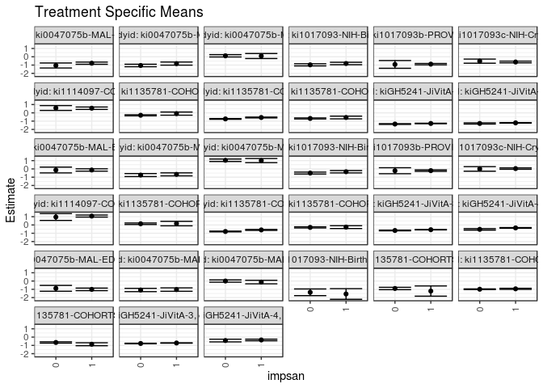

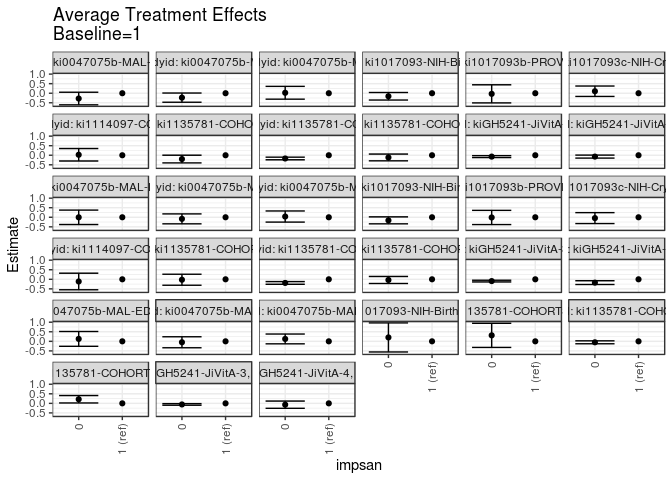

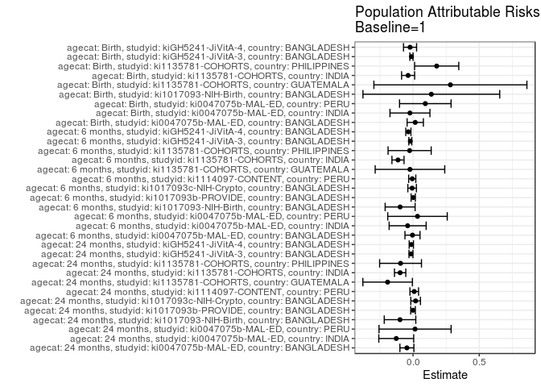

## Results Table

### Parameter: TSM

| agecat | studyid | country | intervention_level | baseline_level | estimate | ci_lower | ci_upper |
| --- | --- | --- | --- | --- | --- | --- | --- |
| Birth | ki0047075b-MAL-ED | BANGLADESH | 1 | NA | -1.0069928 | -1.1622256 | -0.8517601 |
| Birth | ki0047075b-MAL-ED | BANGLADESH | 0 | NA | -0.8805463 | -1.2338469 | -0.5272457 |
| Birth | ki0047075b-MAL-ED | INDIA | 1 | NA | -1.0304690 | -1.2379273 | -0.8230107 |
| Birth | ki0047075b-MAL-ED | INDIA | 0 | NA | -1.0790921 | -1.2771601 | -0.8810242 |
| Birth | ki0047075b-MAL-ED | PERU | 1 | NA | -0.1243884 | -0.3361090 | 0.0873321 |
| Birth | ki0047075b-MAL-ED | PERU | 0 | NA | 0.0008551 | -0.1408555 | 0.1425657 |
| Birth | ki1017093-NIH-Birth | BANGLADESH | 1 | NA | -1.5622222 | -2.2052846 | -0.9191599 |
| Birth | ki1017093-NIH-Birth | BANGLADESH | 0 | NA | -1.3584211 | -1.7618042 | -0.9550379 |
| Birth | ki1135781-COHORTS | GUATEMALA | 1 | NA | -1.2116638 | -1.8268955 | -0.5964322 |
| Birth | ki1135781-COHORTS | GUATEMALA | 0 | NA | -0.8991834 | -1.0422208 | -0.7561459 |
| Birth | ki1135781-COHORTS | INDIA | 1 | NA | -0.9401172 | -1.0016189 | -0.8786156 |
| Birth | ki1135781-COHORTS | INDIA | 0 | NA | -0.9910523 | -1.0358569 | -0.9462478 |
| Birth | ki1135781-COHORTS | PHILIPPINES | 1 | NA | -0.8627400 | -1.0401850 | -0.6852951 |
| Birth | ki1135781-COHORTS | PHILIPPINES | 0 | NA | -0.6483969 | -0.7292618 | -0.5675321 |
| Birth | kiGH5241-JiVitA-3 | BANGLADESH | 1 | NA | -0.7120836 | -0.7365557 | -0.6876115 |
| Birth | kiGH5241-JiVitA-3 | BANGLADESH | 0 | NA | -0.7696186 | -0.8044979 | -0.7347393 |
| Birth | kiGH5241-JiVitA-4 | BANGLADESH | 1 | NA | -0.3458437 | -0.4404089 | -0.2512786 |
| Birth | kiGH5241-JiVitA-4 | BANGLADESH | 0 | NA | -0.4152441 | -0.5771903 | -0.2532980 |
| 6 months | ki0047075b-MAL-ED | BANGLADESH | 1 | NA | -0.1313848 | -0.2731717 | 0.0104022 |
| 6 months | ki0047075b-MAL-ED | BANGLADESH | 0 | NA | -0.1335660 | -0.4831777 | 0.2160457 |
| 6 months | ki0047075b-MAL-ED | INDIA | 1 | NA | -0.6599417 | -0.8420786 | -0.4778049 |
| 6 months | ki0047075b-MAL-ED | INDIA | 0 | NA | -0.7428581 | -0.9266490 | -0.5590672 |
| 6 months | ki0047075b-MAL-ED | PERU | 1 | NA | 1.0037465 | 0.7553778 | 1.2521152 |
| 6 months | ki0047075b-MAL-ED | PERU | 0 | NA | 1.0422808 | 0.8926919 | 1.1918698 |
| 6 months | ki1017093-NIH-Birth | BANGLADESH | 1 | NA | -0.3416130 | -0.4826815 | -0.2005445 |
| 6 months | ki1017093-NIH-Birth | BANGLADESH | 0 | NA | -0.5030061 | -0.6186633 | -0.3873489 |
| 6 months | ki1017093b-PROVIDE | BANGLADESH | 1 | NA | -0.2093809 | -0.2967404 | -0.1220214 |
| 6 months | ki1017093b-PROVIDE | BANGLADESH | 0 | NA | -0.2200402 | -0.5815454 | 0.1414651 |
| 6 months | ki1017093c-NIH-Crypto | BANGLADESH | 1 | NA | 0.0405271 | -0.0431865 | 0.1242407 |
| 6 months | ki1017093c-NIH-Crypto | BANGLADESH | 0 | NA | -0.0026180 | -0.2770777 | 0.2718417 |
| 6 months | ki1114097-CONTENT | PERU | 1 | NA | 1.0743380 | 0.9520486 | 1.1966275 |
| 6 months | ki1114097-CONTENT | PERU | 0 | NA | 0.9607523 | 0.5460079 | 1.3754966 |
| 6 months | ki1135781-COHORTS | GUATEMALA | 1 | NA | 0.1689621 | -0.1023633 | 0.4402875 |
| 6 months | ki1135781-COHORTS | GUATEMALA | 0 | NA | 0.1462551 | 0.0542305 | 0.2382798 |
| 6 months | ki1135781-COHORTS | INDIA | 1 | NA | -0.5969963 | -0.6521000 | -0.5418925 |
| 6 months | ki1135781-COHORTS | INDIA | 0 | NA | -0.7870482 | -0.8295460 | -0.7445504 |
| 6 months | ki1135781-COHORTS | PHILIPPINES | 1 | NA | -0.2575037 | -0.4266059 | -0.0884015 |
| 6 months | ki1135781-COHORTS | PHILIPPINES | 0 | NA | -0.2925752 | -0.3628254 | -0.2223250 |
| 6 months | kiGH5241-JiVitA-3 | BANGLADESH | 1 | NA | -0.5724806 | -0.5954334 | -0.5495277 |
| 6 months | kiGH5241-JiVitA-3 | BANGLADESH | 0 | NA | -0.6661190 | -0.7064081 | -0.6258300 |
| 6 months | kiGH5241-JiVitA-4 | BANGLADESH | 1 | NA | -0.3549222 | -0.3964520 | -0.3133923 |
| 6 months | kiGH5241-JiVitA-4 | BANGLADESH | 0 | NA | -0.5284852 | -0.6190170 | -0.4379533 |
| 24 months | ki0047075b-MAL-ED | BANGLADESH | 1 | NA | -0.7746574 | -0.9065735 | -0.6427412 |
| 24 months | ki0047075b-MAL-ED | BANGLADESH | 0 | NA | -1.0526565 | -1.3531429 | -0.7521702 |
| 24 months | ki0047075b-MAL-ED | INDIA | 1 | NA | -0.8230785 | -1.0076029 | -0.6385541 |
| 24 months | ki0047075b-MAL-ED | INDIA | 0 | NA | -1.0533418 | -1.2046180 | -0.9020657 |
| 24 months | ki0047075b-MAL-ED | PERU | 1 | NA | 0.0910309 | -0.2109093 | 0.3929711 |
| 24 months | ki0047075b-MAL-ED | PERU | 0 | NA | 0.1148878 | -0.0270502 | 0.2568259 |
| 24 months | ki1017093-NIH-Birth | BANGLADESH | 1 | NA | -0.8134524 | -0.9603334 | -0.6665713 |
| 24 months | ki1017093-NIH-Birth | BANGLADESH | 0 | NA | -0.9720467 | -1.1030440 | -0.8410495 |
| 24 months | ki1017093b-PROVIDE | BANGLADESH | 1 | NA | -0.8896822 | -0.9744620 | -0.8049024 |
| 24 months | ki1017093b-PROVIDE | BANGLADESH | 0 | NA | -0.9224958 | -1.3879392 | -0.4570524 |
| 24 months | ki1017093c-NIH-Crypto | BANGLADESH | 1 | NA | -0.6313272 | -0.7361613 | -0.5264930 |
| 24 months | ki1017093c-NIH-Crypto | BANGLADESH | 0 | NA | -0.5281649 | -0.7782192 | -0.2781106 |
| 24 months | ki1114097-CONTENT | PERU | 1 | NA | 0.5575876 | 0.4113724 | 0.7038027 |
| 24 months | ki1114097-CONTENT | PERU | 0 | NA | 0.5824347 | 0.2908939 | 0.8739755 |
| 24 months | ki1135781-COHORTS | GUATEMALA | 1 | NA | -0.0944504 | -0.2854846 | 0.0965838 |
| 24 months | ki1135781-COHORTS | GUATEMALA | 0 | NA | -0.2932402 | -0.3564591 | -0.2300213 |
| 24 months | ki1135781-COHORTS | INDIA | 1 | NA | -0.5633147 | -0.6172687 | -0.5093607 |
| 24 months | ki1135781-COHORTS | INDIA | 0 | NA | -0.7327206 | -0.7751687 | -0.6902724 |
| 24 months | ki1135781-COHORTS | PHILIPPINES | 1 | NA | -0.5622590 | -0.7275725 | -0.3969456 |
| 24 months | ki1135781-COHORTS | PHILIPPINES | 0 | NA | -0.6780770 | -0.7410110 | -0.6151429 |
| 24 months | kiGH5241-JiVitA-3 | BANGLADESH | 1 | NA | -1.2816090 | -1.3096193 | -1.2535987 |
| 24 months | kiGH5241-JiVitA-3 | BANGLADESH | 0 | NA | -1.3524297 | -1.3967838 | -1.3080757 |
| 24 months | kiGH5241-JiVitA-4 | BANGLADESH | 1 | NA | -1.2104353 | -1.2453349 | -1.1755357 |
| 24 months | kiGH5241-JiVitA-4 | BANGLADESH | 0 | NA | -1.2811943 | -1.3527649 | -1.2096238 |

### Parameter: E(Y)

| agecat | studyid | country | intervention_level | baseline_level | estimate | ci_lower | ci_upper |
| --- | --- | --- | --- | --- | --- | --- | --- |
| Birth | ki0047075b-MAL-ED | BANGLADESH | NA | NA | -0.9902252 | -1.1311070 | -0.8493435 |
| Birth | ki0047075b-MAL-ED | INDIA | NA | NA | -1.0536702 | -1.1965043 | -0.9108361 |
| Birth | ki0047075b-MAL-ED | PERU | NA | NA | -0.0315638 | -0.1495606 | 0.0864330 |
| Birth | ki1017093-NIH-Birth | BANGLADESH | NA | NA | -1.4239286 | -1.7688028 | -1.0790544 |
| Birth | ki1135781-COHORTS | GUATEMALA | NA | NA | -0.9294432 | -1.0701697 | -0.7887168 |
| Birth | ki1135781-COHORTS | INDIA | NA | NA | -0.9771733 | -1.0119896 | -0.9423570 |
| Birth | ki1135781-COHORTS | PHILIPPINES | NA | NA | -0.6841030 | -0.7582767 | -0.6099293 |
| Birth | kiGH5241-JiVitA-3 | BANGLADESH | NA | NA | -0.7238913 | -0.7437437 | -0.7040388 |
| Birth | kiGH5241-JiVitA-4 | BANGLADESH | NA | NA | -0.3683163 | -0.4490504 | -0.2875821 |
| 6 months | ki0047075b-MAL-ED | BANGLADESH | NA | NA | -0.1354618 | -0.2647919 | -0.0061317 |
| 6 months | ki0047075b-MAL-ED | INDIA | NA | NA | -0.7004578 | -0.8268704 | -0.5740452 |
| 6 months | ki0047075b-MAL-ED | PERU | NA | NA | 1.0376236 | 0.9141918 | 1.1610554 |
| 6 months | ki1017093-NIH-Birth | BANGLADESH | NA | NA | -0.4389101 | -0.5279432 | -0.3498771 |
| 6 months | ki1017093b-PROVIDE | BANGLADESH | NA | NA | -0.2080201 | -0.2927357 | -0.1233045 |
| 6 months | ki1017093c-NIH-Crypto | BANGLADESH | NA | NA | 0.0336790 | -0.0458848 | 0.1132428 |
| 6 months | ki1114097-CONTENT | PERU | NA | NA | 1.0684318 | 0.9515274 | 1.1853362 |
| 6 months | ki1135781-COHORTS | GUATEMALA | NA | NA | 0.1458511 | 0.0589571 | 0.2327450 |
| 6 months | ki1135781-COHORTS | INDIA | NA | NA | -0.7104855 | -0.7428053 | -0.6781657 |
| 6 months | ki1135781-COHORTS | PHILIPPINES | NA | NA | -0.2830286 | -0.3471028 | -0.2189545 |
| 6 months | kiGH5241-JiVitA-3 | BANGLADESH | NA | NA | -0.5931476 | -0.6127125 | -0.5735828 |
| 6 months | kiGH5241-JiVitA-4 | BANGLADESH | NA | NA | -0.3901595 | -0.4274150 | -0.3529041 |
| 24 months | ki0047075b-MAL-ED | BANGLADESH | NA | NA | -0.8208255 | -0.9429246 | -0.6987264 |
| 24 months | ki0047075b-MAL-ED | INDIA | NA | NA | -0.9496667 | -1.0657716 | -0.8335618 |
| 24 months | ki0047075b-MAL-ED | PERU | NA | NA | 0.1064286 | -0.0147106 | 0.2275677 |
| 24 months | ki1017093-NIH-Birth | BANGLADESH | NA | NA | -0.9115790 | -1.0095022 | -0.8136559 |
| 24 months | ki1017093b-PROVIDE | BANGLADESH | NA | NA | -0.8896187 | -0.9726240 | -0.8066134 |
| 24 months | ki1017093c-NIH-Crypto | BANGLADESH | NA | NA | -0.6115706 | -0.7075788 | -0.5155624 |
| 24 months | ki1114097-CONTENT | PERU | NA | NA | 0.5668293 | 0.4302437 | 0.7034148 |
| 24 months | ki1135781-COHORTS | GUATEMALA | NA | NA | -0.2861905 | -0.3461594 | -0.2262216 |
| 24 months | ki1135781-COHORTS | INDIA | NA | NA | -0.6606874 | -0.6938402 | -0.6275347 |
| 24 months | ki1135781-COHORTS | PHILIPPINES | NA | NA | -0.6564149 | -0.7144543 | -0.5983756 |
| 24 months | kiGH5241-JiVitA-3 | BANGLADESH | NA | NA | -1.2970418 | -1.3203361 | -1.2737475 |
| 24 months | kiGH5241-JiVitA-4 | BANGLADESH | NA | NA | -1.2231776 | -1.2550332 | -1.1913220 |

### Parameter: ATE

| agecat | studyid | country | intervention_level | baseline_level | estimate | ci_lower | ci_upper |
| --- | --- | --- | --- | --- | --- | --- | --- |
| Birth | ki0047075b-MAL-ED | BANGLADESH | 1 | 1 | 0.0000000 | 0.0000000 | 0.0000000 |
| Birth | ki0047075b-MAL-ED | BANGLADESH | 0 | 1 | 0.1264465 | -0.2603648 | 0.5132578 |
| Birth | ki0047075b-MAL-ED | INDIA | 1 | 1 | 0.0000000 | 0.0000000 | 0.0000000 |
| Birth | ki0047075b-MAL-ED | INDIA | 0 | 1 | -0.0486231 | -0.3366428 | 0.2393965 |
| Birth | ki0047075b-MAL-ED | PERU | 1 | 1 | 0.0000000 | 0.0000000 | 0.0000000 |
| Birth | ki0047075b-MAL-ED | PERU | 0 | 1 | 0.1252435 | -0.1316915 | 0.3821785 |
| Birth | ki1017093-NIH-Birth | BANGLADESH | 1 | 1 | 0.0000000 | 0.0000000 | 0.0000000 |
| Birth | ki1017093-NIH-Birth | BANGLADESH | 0 | 1 | 0.2038012 | -0.5553083 | 0.9629106 |
| Birth | ki1135781-COHORTS | GUATEMALA | 1 | 1 | 0.0000000 | 0.0000000 | 0.0000000 |
| Birth | ki1135781-COHORTS | GUATEMALA | 0 | 1 | 0.3124804 | -0.3189922 | 0.9439531 |
| Birth | ki1135781-COHORTS | INDIA | 1 | 1 | 0.0000000 | 0.0000000 | 0.0000000 |
| Birth | ki1135781-COHORTS | INDIA | 0 | 1 | -0.0509351 | -0.1269455 | 0.0250753 |
| Birth | ki1135781-COHORTS | PHILIPPINES | 1 | 1 | 0.0000000 | 0.0000000 | 0.0000000 |
| Birth | ki1135781-COHORTS | PHILIPPINES | 0 | 1 | 0.2143431 | 0.0194809 | 0.4092053 |
| Birth | kiGH5241-JiVitA-3 | BANGLADESH | 1 | 1 | 0.0000000 | 0.0000000 | 0.0000000 |
| Birth | kiGH5241-JiVitA-3 | BANGLADESH | 0 | 1 | -0.0575350 | -0.0982267 | -0.0168434 |
| Birth | kiGH5241-JiVitA-4 | BANGLADESH | 1 | 1 | 0.0000000 | 0.0000000 | 0.0000000 |
| Birth | kiGH5241-JiVitA-4 | BANGLADESH | 0 | 1 | -0.0694004 | -0.2580024 | 0.1192016 |
| 6 months | ki0047075b-MAL-ED | BANGLADESH | 1 | 1 | 0.0000000 | 0.0000000 | 0.0000000 |
| 6 months | ki0047075b-MAL-ED | BANGLADESH | 0 | 1 | -0.0021812 | -0.3798189 | 0.3754564 |
| 6 months | ki0047075b-MAL-ED | INDIA | 1 | 1 | 0.0000000 | 0.0000000 | 0.0000000 |
| 6 months | ki0047075b-MAL-ED | INDIA | 0 | 1 | -0.0829164 | -0.3421366 | 0.1763038 |
| 6 months | ki0047075b-MAL-ED | PERU | 1 | 1 | 0.0000000 | 0.0000000 | 0.0000000 |
| 6 months | ki0047075b-MAL-ED | PERU | 0 | 1 | 0.0385343 | -0.2521406 | 0.3292092 |
| 6 months | ki1017093-NIH-Birth | BANGLADESH | 1 | 1 | 0.0000000 | 0.0000000 | 0.0000000 |
| 6 months | ki1017093-NIH-Birth | BANGLADESH | 0 | 1 | -0.1613931 | -0.3440727 | 0.0212865 |
| 6 months | ki1017093b-PROVIDE | BANGLADESH | 1 | 1 | 0.0000000 | 0.0000000 | 0.0000000 |
| 6 months | ki1017093b-PROVIDE | BANGLADESH | 0 | 1 | -0.0106593 | -0.3823472 | 0.3610287 |
| 6 months | ki1017093c-NIH-Crypto | BANGLADESH | 1 | 1 | 0.0000000 | 0.0000000 | 0.0000000 |
| 6 months | ki1017093c-NIH-Crypto | BANGLADESH | 0 | 1 | -0.0431451 | -0.3295403 | 0.2432500 |
| 6 months | ki1114097-CONTENT | PERU | 1 | 1 | 0.0000000 | 0.0000000 | 0.0000000 |
| 6 months | ki1114097-CONTENT | PERU | 0 | 1 | -0.1135858 | -0.5464892 | 0.3193176 |
| 6 months | ki1135781-COHORTS | GUATEMALA | 1 | 1 | 0.0000000 | 0.0000000 | 0.0000000 |
| 6 months | ki1135781-COHORTS | GUATEMALA | 0 | 1 | -0.0227070 | -0.3091910 | 0.2637771 |
| 6 months | ki1135781-COHORTS | INDIA | 1 | 1 | 0.0000000 | 0.0000000 | 0.0000000 |
| 6 months | ki1135781-COHORTS | INDIA | 0 | 1 | -0.1900520 | -0.2595600 | -0.1205439 |
| 6 months | ki1135781-COHORTS | PHILIPPINES | 1 | 1 | 0.0000000 | 0.0000000 | 0.0000000 |
| 6 months | ki1135781-COHORTS | PHILIPPINES | 0 | 1 | -0.0350715 | -0.2186232 | 0.1484802 |
| 6 months | kiGH5241-JiVitA-3 | BANGLADESH | 1 | 1 | 0.0000000 | 0.0000000 | 0.0000000 |
| 6 months | kiGH5241-JiVitA-3 | BANGLADESH | 0 | 1 | -0.0936385 | -0.1378900 | -0.0493869 |
| 6 months | kiGH5241-JiVitA-4 | BANGLADESH | 1 | 1 | 0.0000000 | 0.0000000 | 0.0000000 |
| 6 months | kiGH5241-JiVitA-4 | BANGLADESH | 0 | 1 | -0.1735630 | -0.2723331 | -0.0747929 |
| 24 months | ki0047075b-MAL-ED | BANGLADESH | 1 | 1 | 0.0000000 | 0.0000000 | 0.0000000 |
| 24 months | ki0047075b-MAL-ED | BANGLADESH | 0 | 1 | -0.2779992 | -0.6073559 | 0.0513575 |
| 24 months | ki0047075b-MAL-ED | INDIA | 1 | 1 | 0.0000000 | 0.0000000 | 0.0000000 |
| 24 months | ki0047075b-MAL-ED | INDIA | 0 | 1 | -0.2302633 | -0.4700561 | 0.0095295 |
| 24 months | ki0047075b-MAL-ED | PERU | 1 | 1 | 0.0000000 | 0.0000000 | 0.0000000 |
| 24 months | ki0047075b-MAL-ED | PERU | 0 | 1 | 0.0238569 | -0.3099750 | 0.3576889 |
| 24 months | ki1017093-NIH-Birth | BANGLADESH | 1 | 1 | 0.0000000 | 0.0000000 | 0.0000000 |
| 24 months | ki1017093-NIH-Birth | BANGLADESH | 0 | 1 | -0.1585944 | -0.3556282 | 0.0384395 |
| 24 months | ki1017093b-PROVIDE | BANGLADESH | 1 | 1 | 0.0000000 | 0.0000000 | 0.0000000 |
| 24 months | ki1017093b-PROVIDE | BANGLADESH | 0 | 1 | -0.0328136 | -0.5057207 | 0.4400935 |
| 24 months | ki1017093c-NIH-Crypto | BANGLADESH | 1 | 1 | 0.0000000 | 0.0000000 | 0.0000000 |
| 24 months | ki1017093c-NIH-Crypto | BANGLADESH | 0 | 1 | 0.1031623 | -0.1689546 | 0.3752791 |
| 24 months | ki1114097-CONTENT | PERU | 1 | 1 | 0.0000000 | 0.0000000 | 0.0000000 |
| 24 months | ki1114097-CONTENT | PERU | 0 | 1 | 0.0248472 | -0.3011894 | 0.3508837 |
| 24 months | ki1135781-COHORTS | GUATEMALA | 1 | 1 | 0.0000000 | 0.0000000 | 0.0000000 |
| 24 months | ki1135781-COHORTS | GUATEMALA | 0 | 1 | -0.1987898 | -0.4006970 | 0.0031174 |
| 24 months | ki1135781-COHORTS | INDIA | 1 | 1 | 0.0000000 | 0.0000000 | 0.0000000 |
| 24 months | ki1135781-COHORTS | INDIA | 0 | 1 | -0.1694059 | -0.2375566 | -0.1012551 |
| 24 months | ki1135781-COHORTS | PHILIPPINES | 1 | 1 | 0.0000000 | 0.0000000 | 0.0000000 |
| 24 months | ki1135781-COHORTS | PHILIPPINES | 0 | 1 | -0.1158179 | -0.2931317 | 0.0614959 |
| 24 months | kiGH5241-JiVitA-3 | BANGLADESH | 1 | 1 | 0.0000000 | 0.0000000 | 0.0000000 |
| 24 months | kiGH5241-JiVitA-3 | BANGLADESH | 0 | 1 | -0.0708207 | -0.1216677 | -0.0199737 |
| 24 months | kiGH5241-JiVitA-4 | BANGLADESH | 1 | 1 | 0.0000000 | 0.0000000 | 0.0000000 |
| 24 months | kiGH5241-JiVitA-4 | BANGLADESH | 0 | 1 | -0.0707591 | -0.1488724 | 0.0073542 |

### Parameter: PAR

| agecat | studyid | country | intervention_level | baseline_level | estimate | ci_lower | ci_upper |
| --- | --- | --- | --- | --- | --- | --- | --- |
| Birth | ki0047075b-MAL-ED | BANGLADESH | 1 | NA | 0.0167676 | -0.0446491 | 0.0781843 |
| Birth | ki0047075b-MAL-ED | INDIA | 1 | NA | -0.0232012 | -0.1740635 | 0.1276611 |
| Birth | ki0047075b-MAL-ED | PERU | 1 | NA | 0.0928246 | -0.1017445 | 0.2873937 |
| Birth | ki1017093-NIH-Birth | BANGLADESH | 1 | NA | 0.1382937 | -0.3780659 | 0.6546532 |
| Birth | ki1135781-COHORTS | GUATEMALA | 1 | NA | 0.2822206 | -0.2954537 | 0.8598950 |
| Birth | ki1135781-COHORTS | INDIA | 1 | NA | -0.0370561 | -0.0863648 | 0.0122527 |
| Birth | ki1135781-COHORTS | PHILIPPINES | 1 | NA | 0.1786370 | 0.0118334 | 0.3454407 |
| Birth | kiGH5241-JiVitA-3 | BANGLADESH | 1 | NA | -0.0118077 | -0.0239167 | 0.0003014 |
| Birth | kiGH5241-JiVitA-4 | BANGLADESH | 1 | NA | -0.0224725 | -0.0719027 | 0.0269577 |
| 6 months | ki0047075b-MAL-ED | BANGLADESH | 1 | NA | -0.0040771 | -0.0609887 | 0.0528346 |
| 6 months | ki0047075b-MAL-ED | INDIA | 1 | NA | -0.0405161 | -0.1802263 | 0.0991942 |
| 6 months | ki0047075b-MAL-ED | PERU | 1 | NA | 0.0338771 | -0.1907678 | 0.2585219 |
| 6 months | ki1017093-NIH-Birth | BANGLADESH | 1 | NA | -0.0972972 | -0.2103562 | 0.0157619 |
| 6 months | ki1017093b-PROVIDE | BANGLADESH | 1 | NA | 0.0013608 | -0.0146435 | 0.0173651 |
| 6 months | ki1017093c-NIH-Crypto | BANGLADESH | 1 | NA | -0.0068482 | -0.0391375 | 0.0254412 |
| 6 months | ki1114097-CONTENT | PERU | 1 | NA | -0.0059062 | -0.0327670 | 0.0209545 |
| 6 months | ki1135781-COHORTS | GUATEMALA | 1 | NA | -0.0231111 | -0.2856828 | 0.2394607 |
| 6 months | ki1135781-COHORTS | INDIA | 1 | NA | -0.1134892 | -0.1591979 | -0.0677806 |
| 6 months | ki1135781-COHORTS | PHILIPPINES | 1 | NA | -0.0255249 | -0.1883327 | 0.1372828 |
| 6 months | kiGH5241-JiVitA-3 | BANGLADESH | 1 | NA | -0.0206670 | -0.0318062 | -0.0095278 |
| 6 months | kiGH5241-JiVitA-4 | BANGLADESH | 1 | NA | -0.0352374 | -0.0547433 | -0.0157314 |
| 24 months | ki0047075b-MAL-ED | BANGLADESH | 1 | NA | -0.0461681 | -0.0991129 | 0.0067766 |
| 24 months | ki0047075b-MAL-ED | INDIA | 1 | NA | -0.1265881 | -0.2584422 | 0.0052659 |
| 24 months | ki0047075b-MAL-ED | PERU | 1 | NA | 0.0153977 | -0.2568436 | 0.2876389 |
| 24 months | ki1017093-NIH-Birth | BANGLADESH | 1 | NA | -0.0981267 | -0.2172447 | 0.0209914 |
| 24 months | ki1017093b-PROVIDE | BANGLADESH | 1 | NA | 0.0000635 | -0.0173090 | 0.0174359 |
| 24 months | ki1017093c-NIH-Crypto | BANGLADESH | 1 | NA | 0.0197566 | -0.0166171 | 0.0561303 |
| 24 months | ki1114097-CONTENT | PERU | 1 | NA | 0.0092417 | -0.0232528 | 0.0417362 |
| 24 months | ki1135781-COHORTS | GUATEMALA | 1 | NA | -0.1917400 | -0.3786926 | -0.0047875 |
| 24 months | ki1135781-COHORTS | INDIA | 1 | NA | -0.0973727 | -0.1401627 | -0.0545828 |
| 24 months | ki1135781-COHORTS | PHILIPPINES | 1 | NA | -0.0941559 | -0.2521225 | 0.0638107 |
| 24 months | kiGH5241-JiVitA-3 | BANGLADESH | 1 | NA | -0.0154328 | -0.0302961 | -0.0005695 |
| 24 months | kiGH5241-JiVitA-4 | BANGLADESH | 1 | NA | -0.0127423 | -0.0288392 | 0.0033546 |